# Pizza Sales Analysis & Revenue Forecasting

Jonathan Katz

2025-11-30

# Introduction

**Business Context:** A pizza restaurant wants to better understand their sales patterns and forecast future revenue to improve staffing, inventory, and operations.

**Questions We’re Answering:**

1. What will total sales revenue be for the next 7 days?
2. What are the peak hours for orders?
3. Which day of the week has the highest sales?
4. What is the best-selling pizza?
5. What is the most popular pizza size?
6. What is the average order value?

# Setup & Load Data

```r
# Load libraries
library(tidyverse)
library(lubridate)
library(scales)
library(readxl)
library(knitr)
library(kableExtra)

# Set theme for all plots
theme_set(theme_minimal(base_size = 12))
```

```r
# Load data
pizza <- read_excel("../data/raw/Data Model - Pizza Sales.xlsx")

# Quick look at the data
glimpse(pizza)
```

```
## Rows: 48,620
## Columns: 12
## $ order_details_id  <dbl> 1, 2, 3, 4, 5, 6, 7, 8, 9, 10, 11, 12, 13, 14, 15, 1…
## $ order_id          <dbl> 1, 2, 2, 2, 2, 2, 3, 3, 4, 5, 6, 6, 7, 8, 9, 9, 9, 9…
## $ pizza_id          <chr> "hawaiian_m", "classic_dlx_m", "five_cheese_l", "ita…
## $ quantity          <dbl> 1, 1, 1, 1, 1, 1, 1, 1, 1, 1, 1, 1, 1, 1, 1, 1, 1, 1…
## $ order_date        <dttm> 2015-01-01, 2015-01-01, 2015-01-01, 2015-01-01, 201…
## $ order_time        <dttm> 1899-12-31 11:38:36, 1899-12-31 11:57:40, 1899-12-3…
## $ unit_price        <dbl> 13.25, 16.00, 18.50, 20.75, 16.00, 20.75, 16.50, 20.…
## $ total_price       <dbl> 13.25, 16.00, 18.50, 20.75, 16.00, 20.75, 16.50, 20.…
## $ pizza_size        <chr> "M", "M", "L", "L", "M", "L", "M", "L", "M", "M", "S…
## $ pizza_category    <chr> "Classic", "Classic", "Veggie", "Supreme", "Veggie",…
## $ pizza_ingredients <chr> "Sliced Ham, Pineapple, Mozzarella Cheese", "Peppero…
## $ pizza_name        <chr> "The Hawaiian Pizza", "The Classic Deluxe Pizza", "T…
```

```r
# Clean and prepare data
pizza <- pizza %>%
  mutate(
    order_date = as.Date(order_date),
    order_hour = hour(hms(order_time)),
    day_of_week = wday(order_date, label = TRUE, week_start = 1),
    month = month(order_date, label = TRUE)
  )

# Confirm data range
cat("Date range:", as.character(min(pizza$order_date)), "to", as.character(max(pizza$order_date)), "\n")
```

```
## Date range: 2015-01-01 to 2015-12-31
```

```r
cat("Total orders:", format(n_distinct(pizza$order_id), big.mark = ","), "\n")
```

```
## Total orders: 21,350
```

```r
cat("Total revenue: $", format(sum(pizza$total_price), big.mark = ","), "\n")
```

```
## Total revenue: $ 817,860
```

# Question 1: What will total sales revenue be for the next 7 days?

*This question will be answered in the forecasting notebook (02_forecasting.Rmd). Here we prepare the daily sales data.*

```r
# Aggregate daily sales for forecasting
daily_sales <- pizza %>%
  group_by(order_date) %>%
  summarise(
    total_revenue = sum(total_price),
    total_orders = n_distinct(order_id),
    total_pizzas = sum(quantity),
    .groups = "drop"
  )

# Preview daily sales
daily_sales %>%
  head(10) %>%
  kable(format.args = list(big.mark = ",")) %>%
  kable_styling(bootstrap_options = c("striped", "hover"))
```

| order_date | total_revenue | total_orders | total_pizzas |
| --- | --- | --- | --- |
| 2015-01-01 | 2,713.85 | 69 | 162 |
| 2015-01-02 | 2,731.90 | 67 | 165 |
| 2015-01-03 | 2,662.40 | 66 | 158 |
| 2015-01-04 | 1,755.45 | 52 | 106 |
| 2015-01-05 | 2,065.95 | 54 | 125 |
| 2015-01-06 | 2,428.95 | 64 | 147 |
| 2015-01-07 | 2,202.20 | 58 | 138 |
| 2015-01-08 | 2,838.35 | 72 | 173 |
| 2015-01-09 | 2,127.35 | 62 | 127 |
| 2015-01-10 | 2,463.95 | 65 | 146 |

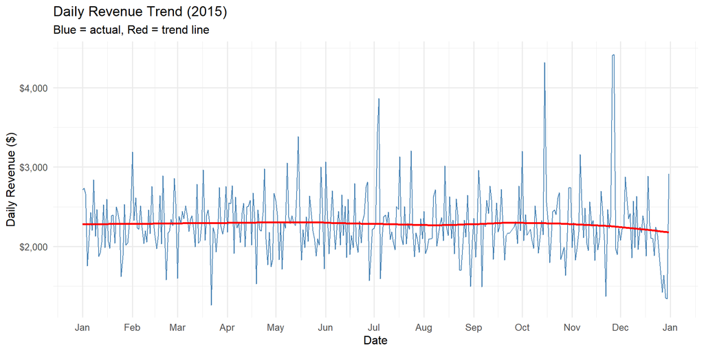

```r
# Plot daily revenue trend
daily_sales %>%
  ggplot(aes(x = order_date, y = total_revenue)) +
  geom_line(color = "steelblue", linewidth = 0.5) +
  geom_smooth(method = "loess", color = "red", se = FALSE, linewidth = 1) +
  labs(
    title = "Daily Revenue Trend (2015)",
    subtitle = "Blue = actual, Red = trend line",
    x = "Date",
    y = "Daily Revenue ($)"
  ) +
  scale_y_continuous(labels = dollar) +
  scale_x_date(date_breaks = "1 month", date_labels = "%b")
```

**Observation:** Revenue is relatively stable throughout the year with some weekly variation. No strong upward or downward trend.

# Question 2: What are the peak hours for orders?

[figure not shown]

```r
# Orders by hour
hourly_orders <- pizza %>%
  group_by(order_hour) %>%
  summarise(
    total_orders = n_distinct(order_id),
    total_revenue = sum(total_price),
    .groups = "drop"
  )

# Plot
hourly_orders %>%
  ggplot(aes(x = order_hour, y = total_orders)) +
  geom_col(fill = "steelblue", alpha = 0.8) +
  geom_text(aes(label = comma(total_orders)), vjust = -0.5, size = 3) +
  labs(
    title = "What are the peak hours for orders?",
    subtitle = "Total orders by hour of day (2015)",
    x = "Hour of Day",
    y = "Number of Orders"
  ) +
  scale_x_continuous(breaks = seq(0, 23, 1)) +
  scale_y_continuous(labels = comma, expand = expansion(mult = c(0, 0.1)))
```

```r
# Top 3 peak hours
top_hours <- hourly_orders %>%
  arrange(desc(total_orders)) %>%
  head(3)

cat("Peak Hours:\n")
```

```
## Peak Hours:
```

```r
cat("1st:", top_hours$order_hour[1], ":00 -", comma(top_hours$total_orders[1]), "orders\n")
```

```
## 1st: NA :00 - 21,350 orders
```

```r
cat("2nd:", top_hours$order_hour[2], ":00 -", comma(top_hours$total_orders[2]), "orders\n")
```

```
## 2nd: NA :00 - NA orders
```

```r
cat("3rd:", top_hours$order_hour[3], ":00 -", comma(top_hours$total_orders[3]), "orders\n")
```

```
## 3rd: NA :00 - NA orders
```

# Question 3: Which day of the week has the highest sales?

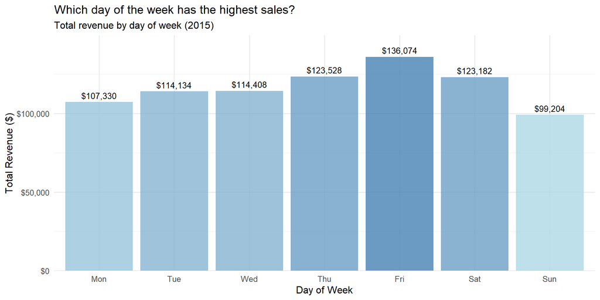

```r
# Sales by day of week
dow_sales <- pizza %>%
  group_by(day_of_week) %>%
  summarise(
    total_revenue = sum(total_price),
    total_orders = n_distinct(order_id),
    avg_daily_revenue = total_revenue / 52,  # 52 weeks in a year
    .groups = "drop"
  )

# Plot
dow_sales %>%
  ggplot(aes(x = day_of_week, y = total_revenue, fill = total_revenue)) +
  geom_col(alpha = 0.8, show.legend = FALSE) +
  geom_text(aes(label = dollar(total_revenue, accuracy = 1)), vjust = -0.5, size = 3.5) +
  scale_fill_gradient(low = "lightblue", high = "steelblue") +
  labs(
    title = "Which day of the week has the highest sales?",
    subtitle = "Total revenue by day of week (2015)",
    x = "Day of Week",
    y = "Total Revenue ($)"
  ) +
  scale_y_continuous(labels = dollar, expand = expansion(mult = c(0, 0.1)))
```

```r
# Best and worst days
best_day <- dow_sales %>% filter(total_revenue == max(total_revenue))
worst_day <- dow_sales %>% filter(total_revenue == min(total_revenue))

cat("Best day:", as.character(best_day$day_of_week), "- $", comma(best_day$total_revenue), "\n")
```

```
## Best day: Fri - $ 136,074
```

```r
cat("Worst day:", as.character(worst_day$day_of_week), "- $", comma(worst_day$total_revenue), "\n")
```

```
## Worst day: Sun - $ 99,204
```

```r
cat("Difference:", dollar((best_day$total_revenue - worst_day$total_revenue) / worst_day$total_revenue * 100, accuracy = 0.1, prefix = ""), "% more revenue on", as.character(best_day$day_of_week))
```

```
## Difference: 37.2 % more revenue on Fri
```

**Answer:** **Friday** has the highest sales, followed by Thursday and Saturday. Sunday has the lowest sales — consider reduced hours or staffing.

# Question 4: What is the best-selling pizza?

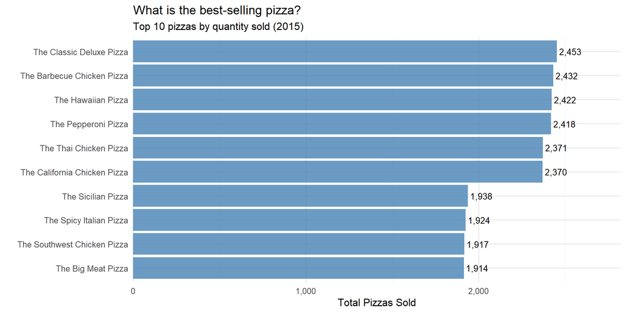

```r
# Top 10 pizzas by quantity sold
top_pizzas <- pizza %>%
  group_by(pizza_name) %>%
  summarise(
    total_sold = sum(quantity),
    total_revenue = sum(total_price),
    .groups = "drop"
  ) %>%
  arrange(desc(total_sold)) %>%
  head(10)

# Plot
top_pizzas %>%
  ggplot(aes(x = reorder(pizza_name, total_sold), y = total_sold)) +
  geom_col(fill = "steelblue", alpha = 0.8) +
  geom_text(aes(label = comma(total_sold)), hjust = -0.1, size = 3.5) +
  coord_flip() +
  labs(
    title = "What is the best-selling pizza?",
    subtitle = "Top 10 pizzas by quantity sold (2015)",
    x = "",
    y = "Total Pizzas Sold"
  ) +
  scale_y_continuous(labels = comma, expand = expansion(mult = c(0, 0.15)))
```

```r
cat("Best-selling pizza:", top_pizzas$pizza_name[1], "\n")
```

```
## Best-selling pizza: The Classic Deluxe Pizza
```

```r
cat("Total sold:", comma(top_pizzas$total_sold[1]), "pizzas\n")
```

```
## Total sold: 2,453 pizzas
```

```r
cat("Total revenue: $", comma(top_pizzas$total_revenue[1]), "\n")
```

```
## Total revenue: $ 38,180
```

**Answer:** **The Classic Deluxe Pizza** is the best-seller with over 2,400 pizzas sold, generating significant revenue.

# Question 5: What is the most popular pizza size?

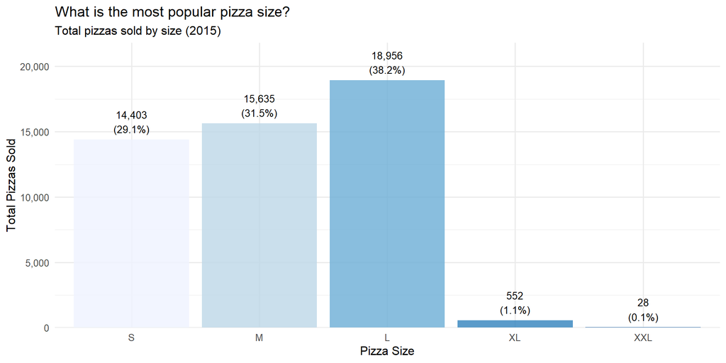

```r
# Sales by size
size_sales <- pizza %>%
  group_by(pizza_size) %>%
  summarise(
    total_sold = sum(quantity),
    total_revenue = sum(total_price),
    pct_of_sales = total_sold / sum(pizza$quantity) * 100,
    .groups = "drop"
  ) %>%
  arrange(desc(total_sold))

# Reorder size factor
size_order <- c("S", "M", "L", "XL", "XXL")
size_sales <- size_sales %>%
  mutate(pizza_size = factor(pizza_size, levels = size_order))

# Plot
size_sales %>%
  ggplot(aes(x = pizza_size, y = total_sold, fill = pizza_size)) +
  geom_col(alpha = 0.8, show.legend = FALSE) +
  geom_text(aes(label = paste0(comma(total_sold), "\n(", round(pct_of_sales, 1), "%)")),
            vjust = -0.3, size = 3.5) +
  labs(
    title = "What is the most popular pizza size?",
    subtitle = "Total pizzas sold by size (2015)",
    x = "Pizza Size",
    y = "Total Pizzas Sold"
  ) +
  scale_y_continuous(labels = comma, expand = expansion(mult = c(0, 0.15))) +
  scale_fill_brewer(palette = "Blues")
```

```r
top_size <- size_sales %>% filter(total_sold == max(total_sold))
cat("Most popular size:", top_size$pizza_size, "\n")
```

```
## Most popular size: 3
```

```r
cat("Percentage of all sales:", round(top_size$pct_of_sales, 1), "%\n")
```

```
## Percentage of all sales: 38.2 %
```